# Homework07

Jorge Ruiz Arocho

2018 M03 07

#### Creating Fake Data Sets To Explore Hypotheses

```r
library(TeachingDemos)
library(ggplot2)
```

##### Specify the sample sizes, means, and variances for each group that would be reasonable if your hypothesis were true.

Ho : leaf area lost by herbivory in cultivated crops = leaf area lost by herbivory in wild ancestors Ha : leaf area lost by herbivory in cultivated crops > leaf area lost by herbivory in wild ancestors

```r
n = 300
HerbCult <- rnorm(n, mean= 18.6, sd= 3) # The mean and sd was selected keeping in mind previous researches that suggest that cultivated crops are more suceptible to suffer from more herbivory in comparison to their wild counterpart. This set of observation is run on an hypotetical leaf with an area of 30 cm2.
HerbWild <- rnorm(n, mean= 13.7, sd= 3)
head(HerbCult)
```

```
## [1] 18.66601 17.54560 16.39852 20.26617 19.63359 16.54933
```

```r
head(HerbWild)
```

```
## [1]  9.135470 16.895103  9.110032 14.582982 14.983561 13.665155
```

#### Using the methods we have covered in class, write a simple function to create a random data set that has these attributes. Organize these data into a data frame with the appropriate structure.

```r
HerbivoryArea <- function(mean1=18.6, mean2= 13.7, n1 = 300, n2 = 300, sd1 = 3, sd2 = 3) {
  mydf <- data.frame(Cultivated = rnorm(mean=mean1, n=n1, sd=sd1), Wild = rnorm(n =n2, mean=mean2, sd = sd2))
  return(mydf)
} # In this fuction I assigned the mean, the sample size and the sd for each group (Wild and Cultivated) and organize it in a data.frame

myDF <- HerbivoryArea(mean1=18.6, mean2 = 13.7)
head(myDF)
```

```
##   Cultivated     Wild
## 1   18.01646 16.14977
## 2   18.91048 16.09565
## 3   18.24040 14.11467
## 4   21.71295 19.60197
## 5   18.79546 12.01517
## 6   21.04622 11.57271
```

```r
library(reshape2)
HerbData <- melt(myDF) # Here I am assigning the categories (Cultivated and Wild) to a column and I am pairing them with the observe values of leaf herbivory.
head(HerbData)
```

```
##     variable    value
## 1 Cultivated 18.01646
## 2 Cultivated 18.91048
## 3 Cultivated 18.24040
## 4 Cultivated 21.71295
## 5 Cultivated 18.79546
## 6 Cultivated 21.04622
```

#### Now write a simple function to analyze the data (probably as an ANOVA or regression analysis, but possibly as a logistic regression or contingency table analysis. Write another function to generate a useful graph of the data.

```r
ANOmodel <- aov(value~variable, data=HerbData)
summary(ANOmodel)
```

```
##              Df Sum Sq Mean Sq F value Pr(>F)
## variable      1   3859    3859   429.9 <2e-16 ***
## Residuals   598   5369       9
## ---
## Signif. codes:  0 '***' 0.001 '**' 0.01 '*' 0.05 '.' 0.1 ' ' 1
```

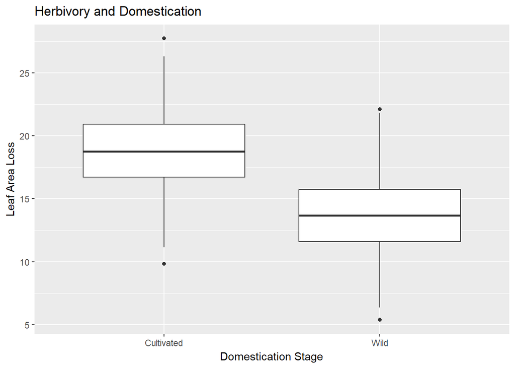

```r
ANOPlot <- ggplot(data=HerbData,
                  aes(x=variable, y=value, fill=value)) + geom_boxplot() + ggtitle("Herbivory and Domestication") + ylab("Leaf Area Loss") + xlab("Domestication Stage")
print(ANOPlot)
```

#### Try running your analysis multiple times to get a feeling for how variable the results are with the same parameters, but different sets of random numbers.

```r
HerbivoryArea <- function(mean1=18.6, mean2= 13.7, n1 = 300, n2 = 300, sd1 = 3, sd2 = 3) {
  mydf <- data.frame(Cultivated = rnorm(mean=mean1, n=n1, sd=sd1), Wild = rnorm(n =n2, mean=mean2, sd = sd2))
  return(mydf)
}

myDF <- HerbivoryArea(mean1=18.6, mean2 = 13.7)
head(myDF)
```

```
##   Cultivated     Wild
## 1   20.51193 12.59300
## 2   23.69045 16.46536
## 3   14.78449 19.38009
## 4   19.59832 11.02427
## 5   20.32101 14.99324
## 6   18.60828 14.78230
```

```r
library(reshape2)
HerbData <- melt(myDF)
ANOmodel <- aov(value~variable, data=HerbData)
summary(ANOmodel)
```

```
##              Df Sum Sq Mean Sq F value Pr(>F)
## variable      1   3571    3571   371.7 <2e-16 ***
## Residuals   598   5745      10
## ---
## Signif. codes:  0 '***' 0.001 '**' 0.01 '*' 0.05 '.' 0.1 ' ' 1
```

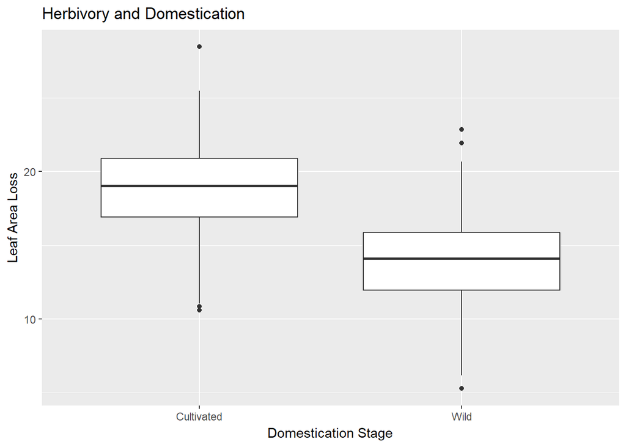

```r
ANOPlot <- ggplot(data=HerbData,
                  aes(x=variable, y=value, fill=value)) + geom_boxplot() + ggtitle("Herbivory and Domestication") + ylab("Leaf Area Loss") + xlab("Domestication Stage")
print(ANOPlot)
```

```r
HerbivoryArea <- function(mean1=18.6, mean2= 13.7, n1 = 300, n2 = 300, sd1 = 3, sd2 = 3) {
  mydf <- data.frame(Cultivated = rnorm(mean=mean1, n=n1, sd=sd1), Wild = rnorm(n =n2, mean=mean2, sd = sd2))
  return(mydf)
}

myDF <- HerbivoryArea(mean1=18.6, mean2 = 13.7)
head(myDF)
```

```
##   Cultivated     Wild
## 1   17.47498 13.00666
## 2   16.81035 17.57379
## 3   17.24058 16.46685
## 4   13.76790 16.06620
## 5   18.95280 15.99114
## 6   15.83719 17.49752
```

```r
library(reshape2)
HerbData <- melt(myDF)
ANOmodel <- aov(value~variable, data=HerbData)
summary(ANOmodel)
```

```
##              Df Sum Sq Mean Sq F value Pr(>F)
## variable      1   3708    3708   403.7 <2e-16 ***
## Residuals   598   5493       9
## ---
## Signif. codes:  0 '***' 0.001 '**' 0.01 '*' 0.05 '.' 0.1 ' ' 1
```

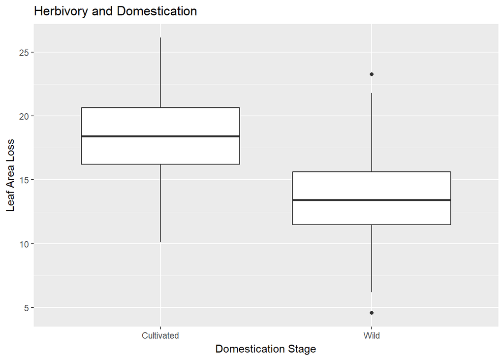

```r
ANOPlot <- ggplot(data=HerbData,
                  aes(x=variable, y=value, fill=value)) + geom_boxplot() + ggtitle("Herbivory and Domestication") + ylab("Leaf Area Loss") + xlab("Domestication Stage")
print(ANOPlot) # We can observe a variability on the final results based on the generation of different sets of data.
```

#### Now begin adjusting the means of the different groups. Given the sample sizes you have chosen, how small can the differences between the groups be (the “effect size”) for you to still detect a significant pattern (p < 0.05)

```r
# HerbivoryArea <- function(mean1=18.6, mean2= 13.7, n1 = 300, n2 = 300, sd1 = 3, sd2 = 3) {
#  mydf <- data.frame(Cultivated = rnorm(mean=mean1, n=n1, sd=sd1), Wild = rnorm(n =n2, mean=mean2, sd = sd2))
#  return(mydf)}

myDF <- HerbivoryArea(mean1=8, mean2 = 5) # In this fuction we can change our parameters to see how small the diffeences between the groups can be, in our example a small difference between the means still result in a significat p-value, but if we use relative different means, the chances of obtaining significant p-values increases. Because we are using a random number generator we will obtain different results everything we run the codes, but the means used in this last function appears to give us significant p-values in a relative high frequency.

head(myDF)
```

```
##   Cultivated     Wild
## 1  10.022269 3.812781
## 2   8.418471 1.024841
## 3  11.765998 6.426224
## 4   4.999453 6.404945
## 5  11.553931 6.467966
## 6   7.239371 4.814825
```

```r
library(reshape2)
HerbData <- melt(myDF)
ANOmodel <- aov(value~variable, data=HerbData)
summary(ANOmodel)
```

```
##              Df Sum Sq Mean Sq F value Pr(>F)
## variable      1   1210    1210   134.5 <2e-16 ***
## Residuals   598   5381       9
## ---
## Signif. codes:  0 '***' 0.001 '**' 0.01 '*' 0.05 '.' 0.1 ' ' 1
```

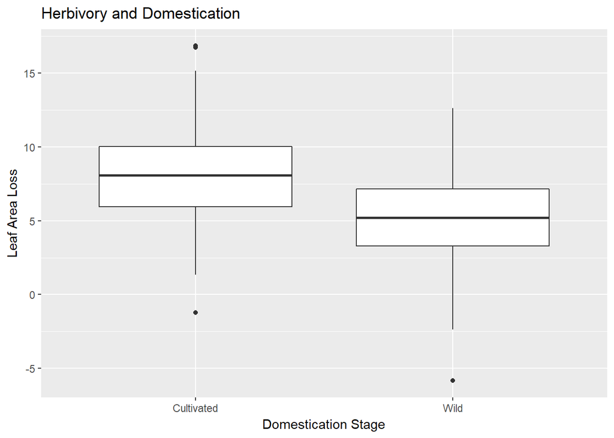

```r
ANOPlot <- ggplot(data=HerbData,
                  aes(x=variable, y=value, fill=value)) + geom_boxplot() + ggtitle("Herbivory and Domestication") + ylab("Leaf Area Loss") + xlab("Domestication Stage")
print(ANOPlot)
```

#### Alternatively, for the effect sizes you originally hypothesized, what is the minimum sample size you would need in order to detect a statistically significant effect. Again, run the model a few times with the same parameter set to get a feeling for the effect of random variation in the data.

```r
# HerbivoryArea <- function(mean1=18.6, mean2= 13.7, n1 = 300, n2 = 300, sd1 = 3, sd2 = 3) {
#  mydf <- data.frame(Cultivated = rnorm(mean=mean1, n=n1, sd=sd1), Wild = rnorm(n =n2, mean=mean2, sd = sd2))
#  return(mydf)}

myDF <- HerbivoryArea(n1=15, n2= 15) # In this fuction we can change our parameters to see the minimun sample size needed to observe a statistically significant effect. Again, a large set of observations (n) give us a better chance of obtaining significant p-values, but because we are using a random number generator we will obtain different results everything we run the codes. The sample size used in this last function appears to give us siignificant p-values in a relative high frequency.

head(myDF)
```

```
##   Cultivated      Wild
## 1   19.09171 14.438742
## 2   20.85667 11.342659
## 3   23.80225 14.271717
## 4   16.54969  9.842204
## 5   23.20584 12.440111
## 6   15.91210 18.587735
```

```r
library(reshape2)
HerbData <- melt(myDF)
ANOmodel <- aov(value~variable, data=HerbData)
summary(ANOmodel)
```

```
##             Df Sum Sq Mean Sq F value   Pr(>F)
## variable     1  216.2   216.2   34.33 2.68e-06 ***
## Residuals   28  176.3     6.3
## ---
## Signif. codes:  0 '***' 0.001 '**' 0.01 '*' 0.05 '.' 0.1 ' ' 1
```

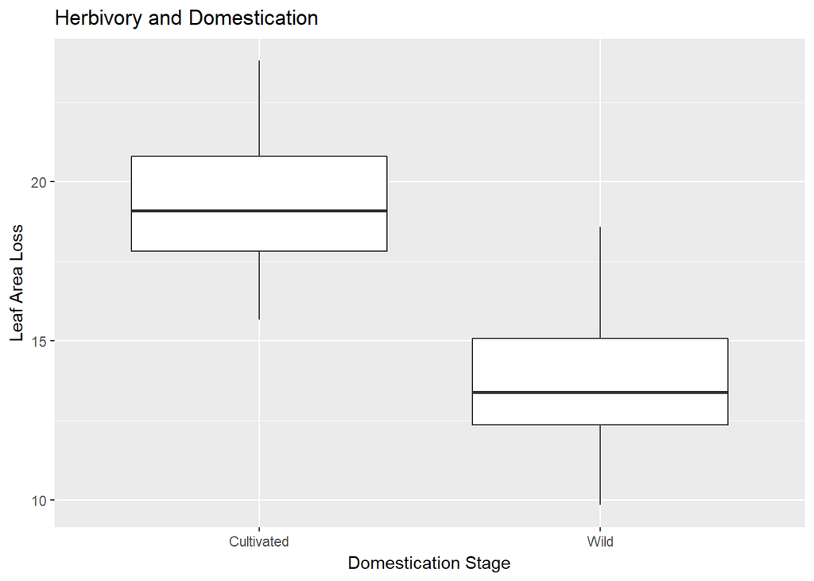

```r
ANOPlot <- ggplot(data=HerbData,
                  aes(x=variable, y=value, fill=value)) + geom_boxplot() + ggtitle("Herbivory and Domestication") + ylab("Leaf Area Loss") + xlab("Domestication Stage")
print(ANOPlot)
```

#### If you have time, try repeating this exercise with one of the more sophisticated distributions, such as the gamma or negative binomial (depending on the kind of data you have). You will have to spend some time figuring out by trial and error the parameter values you will need to generate appropriate means and variances of the different groups.

```r
# In Gamma Distributions
# shape and scale parameters
# mean = shape*scale
# variance = shape*scale^2

n = 300
HerbCult <- rgamma(n, shape=6, scale = 5)
HerbWild <- rgamma(n, shape= 2, scale = 3)

# In the last two functions we created a random data set based on a gamma distribution. We selected the parameter values that goes along with our original hypothesis (cultivated crops are more suceptible to suffer from more herbivory in comparison to their wild counterpart).

head(HerbCult)
```

```
## [1] 71.28109 37.33206 17.85356 36.95928 32.91501 41.92878
```

```r
head(HerbWild)
```

```
## [1]  2.802236 10.594760 10.496518  6.962901  1.721238  3.450544
```

```r
summary(HerbCult)
```

```
##    Min. 1st Qu.  Median    Mean 3rd Qu.    Max.
##   4.307  20.382  28.848  30.928  38.871  87.267
```

```r
summary(HerbWild)
```

```
##    Min. 1st Qu.  Median    Mean 3rd Qu.    Max.
##  0.3224  3.1830  4.9022  5.8267  7.7126 22.1373
```

```r
HerbivoryArea <- function(shape1=6, shape2=2, n1 = 300, n2 = 300, scale1 = 5, scale2 = 3) {
  mydf <- data.frame(Cultivated = rgamma(shape=shape1, n=n1, scale=scale1), Wild = rgamma(shape=shape2, n=n2, scale=scale2))
  return(mydf)
} # In this fuction I assigned the shape and scale for each group (Wild and Cultivated) and organize it in a data.frame

myDF <- HerbivoryArea(shape1=6, shape2=2)
head(myDF)
```

```
##   Cultivated      Wild
## 1   23.62777  3.459876
## 2   25.61847  5.495222
## 3   24.95981  3.466829
## 4   23.05940  6.614101
## 5   27.13743  6.998422
## 6   30.13252 14.356037
```

```r
library(reshape2)
HerbData <- melt(myDF) # Here I am assigning the categories (Cultivated and Wild) to a column and I am pairing them with the observe values of leaf herbivory.
head(HerbData)
```

```
##     variable    value
## 1 Cultivated 23.62777
## 2 Cultivated 25.61847
## 3 Cultivated 24.95981
## 4 Cultivated 23.05940
## 5 Cultivated 27.13743
## 6 Cultivated 30.13252
```

```r
summary(HerbData)
```

```
##        variable       value
##  Cultivated:300   Min.   : 0.159
##  Wild      :300   1st Qu.: 4.745
##                   Median :13.867
##                   Mean   :18.157
##                   3rd Qu.:27.921
##                   Max.   :84.717
```

```r
ANOmodel <- aov(value~variable, data=HerbData)
summary(ANOmodel)
```

```
##              Df Sum Sq Mean Sq F value Pr(>F)
## variable      1  89716   89716   974.4 <2e-16 ***
## Residuals   598  55059      92
## ---
## Signif. codes:  0 '***' 0.001 '**' 0.01 '*' 0.05 '.' 0.1 ' ' 1
```

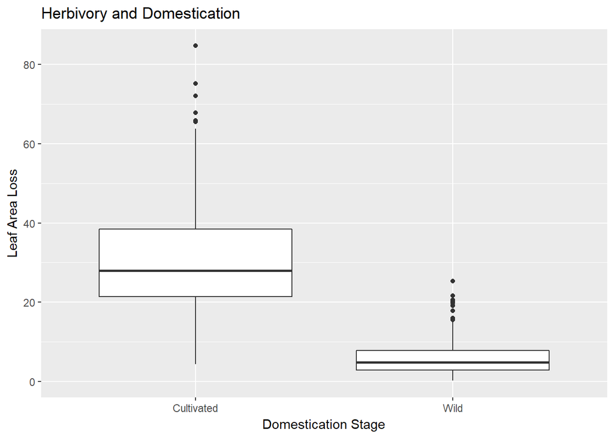

```r
ANOPlot <- ggplot(data=HerbData,
                  aes(x=variable, y=value, fill=value)) + geom_boxplot() + ggtitle("Herbivory and Domestication") + ylab("Leaf Area Loss") + xlab("Domestication Stage")
print(ANOPlot)
```